# Regresión Polinomial

Osmar Dominique Santana Reyes

2025-10-08

# Ejemplo:

Consideremos la base de datos resistencia, realicemos un análisis polinomial (debido al gráfico de dispersión) para explicar la resistencia a la tensión de una bolsa en función del porcentaje de madera dura.

- Variable dependiente(respuesta): Resistencia
- Variable independiente(predictora): Concentración

Veamos el diagrama de dispersión:

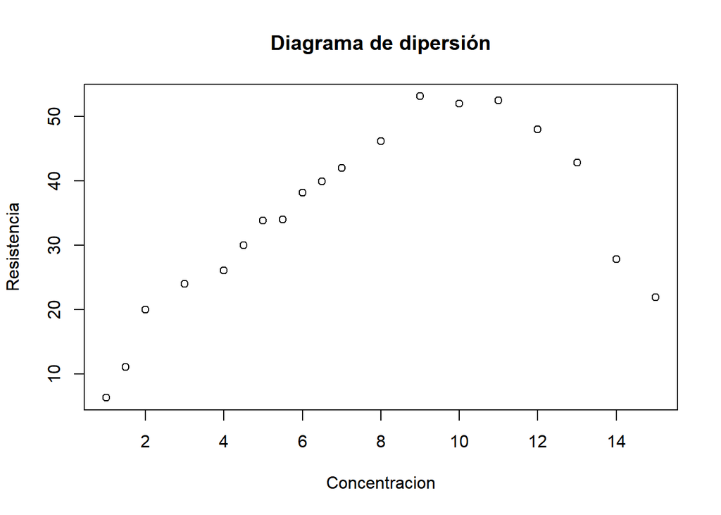

|  | Concentracion | Resistencia |
| --- | --- | --- |
| 1 | 1 | 6.3 |
| 2 | 1.5 | 11.1 |
| 3 | 2 | 20 |
| 4 | 3 | 24 |
| 5 | 4 | 26.1 |
| 6 | 4.5 | 30 |
| 7 | 5 | 33.8 |
| 8 | 5.5 | 34 |
| 9 | 6 | 38.1 |
| 10 | 6.5 | 39.9 |

[output cut: 9 more lines]

## Modelo 1 (lineal)

$$y = a + bx$$

donde $y$ = Resistencia y $x$ = Concentración.

```
##
## Call:
## lm(formula = Resistencia ~ Concentracion, data = Resistencia)
##
## Residuals:
##     Min      1Q  Median      3Q     Max
## -25.986  -3.749   2.938   7.675  15.840
##
## Coefficients:
##               Estimate Std. Error t value Pr(>|t|)
## (Intercept)    21.3213     5.4302   3.926  0.00109 **
## Concentracion   1.7710     0.6478   2.734  0.01414 *
## ---
## Signif. codes:  0 '***' 0.001 '**' 0.01 '*' 0.05 '.' 0.1 ' ' 1
##
## Residual standard error: 11.82 on 17 degrees of freedom
## Multiple R-squared:  0.3054, Adjusted R-squared:  0.2645
## F-statistic: 7.474 on 1 and 17 DF,  p-value: 0.01414
```

Se observa que los dos coeficientes son significativos para el modelo, en este caso, podemos decir que la concentración sí es una variable que nos pueda ayudar a predecir la resitencia. Pero notamos que el R-cuadrado ajustado es muy bajo (0.2645), por lo que este modelo no es muy bueno.

## Modelo 2 (Polinomio cuadrático)

$$y = a + bx + cx^2$$

donde $y$ = Resistencia y $x$ = Concentración.

```
##
## Call:
## lm(formula = Resistencia ~ Concentracion + I(Concentracion^2),
##     data = Resistencia)
##
## Residuals:
##     Min      1Q  Median      3Q     Max
## -5.8503 -3.2482 -0.7267  4.1350  6.5506
##
## Coefficients:
##                    Estimate Std. Error t value Pr(>|t|)
## (Intercept)        -6.67419    3.39971  -1.963   0.0673 .
## Concentracion      11.76401    1.00278  11.731 2.85e-09 ***
## I(Concentracion^2) -0.63455    0.06179 -10.270 1.89e-08 ***
## ---
## Signif. codes:  0 '***' 0.001 '**' 0.01 '*' 0.05 '.' 0.1 ' ' 1
##
## Residual standard error: 4.42 on 16 degrees of freedom
## Multiple R-squared:  0.9085, Adjusted R-squared:  0.8971
## F-statistic: 79.43 on 2 and 16 DF,  p-value: 4.912e-09
```

Notamos que este es un mejor modelo, pasamos de un R-cuadrada ajustada de 0.2645 a una de 0.8971, donde tanto el término lineal como el cuadrático son significativos para el modelo.

## Comparación del Modelo 1 vs el Modelo 2

|  | Res.Df | RSS | Df | Sum of Sq | F | Pr(>F) |
| --- | --- | --- | --- | --- | --- | --- |
| 1 | 17 | 2373.4578 | NA | NA | NA | NA |
| 2 | 16 | 312.6383 | 1 | 2060.82 | 105.4673 | 1.894349e-08 |

Como el p-value $= 1.894 * 10^{-8}$ rechazamos H0, es decir, el modelo con más variables es mejor que el modelo con menos variables.

Por lo que, por el momento, el mejor modelo es un polinomio cuadrático.

$$Resistencia = -6.67419 +
11.76401*Concentracion - 0.63455*Concentracion^2$$

## Modelo 3 (Polinomio cúbico)

$$y = a + bx + cx^2 + dx^3$$

donde $y$ = Resistencia y $x$ = Concentración

```
##
## Call:
## lm(formula = Resistencia ~ Concentracion + I(Concentracion^2) +
##     I(Concentracion^3), data = Resistencia)
##
## Residuals:
##     Min      1Q  Median      3Q     Max
## -4.6250 -1.6109  0.0413  1.5892  5.0216
##
## Coefficients:
##                     Estimate Std. Error t value Pr(>|t|)
## (Intercept)         5.648395   2.954663   1.912   0.0752 .
## Concentracion       3.578489   1.565854   2.285   0.0373 *
## I(Concentracion^2)  0.653635   0.231330   2.826   0.0128 *
## I(Concentracion^3) -0.055188   0.009789  -5.638 4.72e-05 ***
## ---
## Signif. codes:  0 '***' 0.001 '**' 0.01 '*' 0.05 '.' 0.1 ' ' 1
##
## Residual standard error: 2.585 on 15 degrees of freedom
## Multiple R-squared:  0.9707, Adjusted R-squared:  0.9648
## F-statistic: 165.4 on 3 and 15 DF,  p-value: 1.025e-11
```

El R-cuadrado ajustado es mejor, pero los términos ya no son tan significativos, de hecho el intercepto no es significativo.

## Comparación del Modelo 2 vs el Modelo 3

|  | Res.Df | RSS | Df | Sum of Sq | F | Pr(>F) |
| --- | --- | --- | --- | --- | --- | --- |
| 1 | 16 | 312.6383 | NA | NA | NA | NA |
| 2 | 15 | 100.2369 | 1 | 212.4014 | 31.78491 | 4.721725e-05 |

Como el p-value $= 4.722 * 10^{-5}$ rechazamos H0, es decir, el modelo con más variables es mejor que el modelo con menos variables.

Por lo que, por el momento, el mejor modelo es un polinomio cúbico.

$$Resistencia = 5.648395 +
3.578489*Concentracion + 0.653635*Concentracion^2 -
0.055188*Concentracion^3$$

## Modelo 4 (polinomio de grado 4)

$$y = a + bx + cx^2 + dx^3 + ex^4$$

donde $y$ = Resistencia y $x$ = Concentración

```
##
## Call:
## lm(formula = Resistencia ~ Concentracion + I(Concentracion^2) +
##     I(Concentracion^3) + I(Concentracion^4), data = Resistencia)
##
## Residuals:
##     Min      1Q  Median      3Q     Max
## -5.1384 -1.0550 -0.3203  1.0779  4.5030
##
## Coefficients:
##                     Estimate Std. Error t value Pr(>|t|)
## (Intercept)         1.070958   4.679866   0.229   0.8223
## Concentracion       8.049481   3.902170   2.063   0.0582 .
## I(Concentracion^2) -0.517352   0.966390  -0.535   0.6008
## I(Concentracion^3)  0.056575   0.090164   0.627   0.5405
## I(Concentracion^4) -0.003505   0.002812  -1.247   0.2330
## ---
## Signif. codes:  0 '***' 0.001 '**' 0.01 '*' 0.05 '.' 0.1 ' ' 1
##
## Residual standard error: 2.539 on 14 degrees of freedom
## Multiple R-squared:  0.9736, Adjusted R-squared:  0.9661
## F-statistic: 129.1 on 4 and 14 DF,  p-value: 6.994e-11
```

El R-cuadrado ajustado es un poco mejor, pero los términos ya no son significativos para el modelo.

## Comparación del Modelo 3 vs el Modelo 4

|  | Res.Df | RSS | Df | Sum of Sq | F | Pr(>F) |
| --- | --- | --- | --- | --- | --- | --- |
| 1 | 15 | 100.2369 | NA | NA | NA | NA |
| 2 | 14 | 90.2215 | 1 | 10.0154 | 1.554126 | 0.2329827 |

Como el p-value = 0.233 se acepta H0, es decir, el modelo con menos variables es mejor que el modelo con más variables.

De esta manera, el mejor modelo es el cúbico.

Graficando los modelos y el diagrama de dispersión, se obtiene lo siguiente:

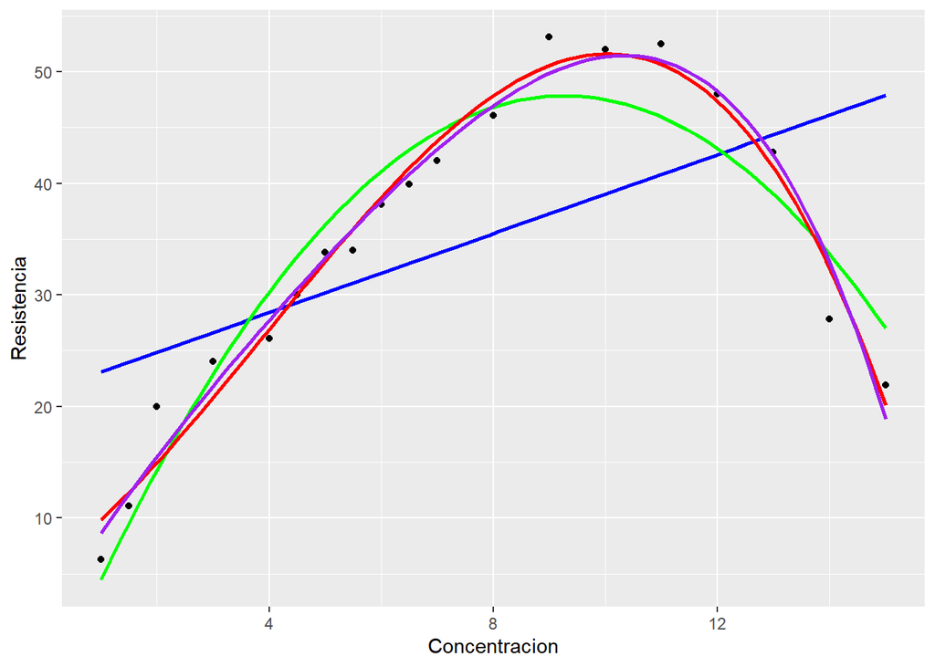

## Mejor modelo:

$$Resistencia = 5.648395 +
3.578489*Concentracion + 0.653635*Concentracion^2 -
0.055188*Concentracion^3$$
con una R-cuadrada ajustada de 0.9648.

## Predicciones

Predecir la resistencia para la concentración: 8.5, 9.5 y 10.5

```
##        fit      lwr      upr
## 1 49.39863 47.37828 51.41898
## 2 51.31818 49.04105 53.59530
## 3 51.39930 48.91376 53.88484
```

```
##        fit      lwr      upr
## 1 49.39863 43.53001 55.26726
## 2 51.31818 45.35628 57.28008
## 3 51.39930 45.35473 57.44387
```

## Verificación de supuestos

Verificar los supuestos de normalidad y homocedasticidad.

```
## Non-constant Variance Score Test
## Variance formula: ~ fitted.values
## Chisquare = 3.158583, Df = 1, p = 0.075529
```

De la prueba de homocedasticidad, se obtiene un p-value de 0.075529 por lo que se acepta la hipótesis nula de que la varianza es constante.

```
##
##  Shapiro-Wilk normality test
##
## data:  residuals(mod3)
## W = 0.99015, p-value = 0.9986
```

Y de la prueba de normalidad se obtiene un p-value de 0.9986 por lo que se acepta la hipótesis nula de que los errores están distribuidos de manera normal.